# novel_intestine_genes

Robert Williams

4/5/2022

Load packages

```r
library(tidyverse)
```

Load data

```r
embryo_intestine_gene_categories <- read_csv(file = "../03_output/intestine_gene_categories/embryo_intestine_gene_categories.csv")
L1_intestine_gene_categories <- read_csv(file = "../03_output/intestine_gene_categories/L1_intestine_gene_categories.csv")
L3_intestine_gene_categories <- read_csv(file = "../03_output/intestine_gene_categories/L3_intestine_gene_categories.csv")
res_embryoGFPplus_vs_embryoGFPminus_ashr_shrunk <- read_csv("../03_output/pairwise_shrunk_DE_results/res_embryoGFPplus_vs_embryoGFPminus_ashr_shrunk.csv")
res_L1GFPplus_vs_L1GFPminus_ashr_shrunk <- read_csv("../03_output/pairwise_shrunk_DE_results/res_L1GFPplus_vs_L1GFPminus_ashr_shrunk.csv")
res_L3GFPplus_vs_L3GFPminus_ashr_shrunk <- read_csv("../03_output/pairwise_shrunk_DE_results/res_L3GFPplus_vs_L3GFPminus_ashr_shrunk.csv")
intestine_genes <- read_delim("../../01_tissue_specific_genes/01_input/genes_direct_and_inferred_for_WBbt_0005772_intestine.txt", delim = "\t",col_names = c("WBGeneID", "gene_name", "Species"))
```

# Embryo genes

```r
embryo_enriched_annotation <- embryo_intestine_gene_categories %>%
  filter(altHyp == "greater") %>%
  left_join(res_embryoGFPplus_vs_embryoGFPminus_ashr_shrunk, by = "WBGeneID") %>%
  left_join(intestine_genes, by = "WBGeneID") %>%
  mutate(annotation = case_when(is.na(gene_name) ~ "unannotated",
                                !is.na(gene_name) ~ "annotated"))

embryo_enriched_annotation %>% filter(annotation == "unannotated") %>% slice_min(padj, n = 10)
```

```
## # A tibble: 10 × 11
##    WBGeneID      altHyp intestine_expre… baseMean log2FoldChange lfcSE    pvalue
##    <chr>         <chr>  <chr>               <dbl>          <dbl> <dbl>     <dbl>
##  1 WBGene000019… great… enriched            3826.           9.92 0.450 7.81e-109
##  2 WBGene000430… great… enriched            1859.           3.35 0.206 1.92e- 61
##  3 WBGene000220… great… enriched            1219.           5.81 0.388 1.44e- 51
##  4 WBGene000091… great… enriched             773.           4.35 0.310 1.10e- 45
##  5 WBGene000216… great… enriched             207.           4.99 0.359 1.08e- 44
##  6 WBGene000019… great… enriched            3218.           6.84 0.501 3.25e- 43
##  7 WBGene000005… great… enriched            1825.           2.68 0.201 2.90e- 42
##  8 WBGene000201… great… enriched            3178.           2.50 0.196 6.08e- 39
##  9 WBGene000173… great… enriched             237.           7.30 0.568 1.15e- 38
## 10 WBGene000019… great… enriched            3707.          11.0  0.877 1.35e- 37
## # … with 4 more variables: padj <dbl>, gene_name <chr>, Species <chr>,
## #   annotation <chr>
```

# L1 genes

```r
L1_enriched_annotation <- L1_intestine_gene_categories %>%
  filter(altHyp == "greater") %>%
  left_join(res_L1GFPplus_vs_L1GFPminus_ashr_shrunk, by = "WBGeneID") %>%
  left_join(intestine_genes, by = "WBGeneID") %>%
  mutate(annotation = case_when(is.na(gene_name) ~ "unannotated",
                                !is.na(gene_name) ~ "annotated"))

L1_enriched_annotation %>% filter(annotation == "unannotated") %>% slice_min(padj, n = 10)
```

```
## # A tibble: 10 × 11
##    WBGeneID       altHyp intestine_expre… baseMean log2FoldChange lfcSE   pvalue
##    <chr>          <chr>  <chr>               <dbl>          <dbl> <dbl>    <dbl>
##  1 WBGene00001940 great… enriched            3826.           7.26 0.564 7.83e-40
##  2 WBGene00017327 great… enriched             237.           6.37 0.613 1.16e-26
##  3 WBGene00020683 great… enriched           10276.           2.11 0.205 4.89e-25
##  4 WBGene00012134 great… enriched             935.           6.80 0.693 2.66e-24
##  5 WBGene00018925 great… enriched             790.           2.71 0.271 9.22e-24
##  6 WBGene00235352 great… enriched             283.           6.82 0.724 1.11e-22
##  7 WBGene00017957 great… enriched             247.           6.50 0.692 1.91e-22
##  8 WBGene00002070 great… enriched            2807.           2.20 0.227 2.26e-22
##  9 WBGene00021820 great… enriched            2260.           2.46 0.258 1.08e-21
## 10 WBGene00001922 great… enriched            3218.           5.70 0.613 1.37e-21
## # … with 4 more variables: padj <dbl>, gene_name <chr>, Species <chr>,
## #   annotation <chr>
```

# L3 genes

```r
L3_enriched_annotation <- L3_intestine_gene_categories %>%
  filter(altHyp == "greater") %>%
  left_join(res_L3GFPplus_vs_L3GFPminus_ashr_shrunk, by = "WBGeneID") %>%
  left_join(intestine_genes, by = "WBGeneID") %>%
  mutate(annotation = case_when(is.na(gene_name) ~ "unannotated",
                                !is.na(gene_name) ~ "annotated"))

L3_enriched_annotation %>% filter(annotation == "unannotated") %>% slice_min(padj, n = 10)
```

```
## # A tibble: 10 × 11
##    WBGeneID       altHyp intestine_expre… baseMean log2FoldChange lfcSE   pvalue
##    <chr>          <chr>  <chr>               <dbl>          <dbl> <dbl>    <dbl>
##  1 WBGene00001940 great… enriched            3826.           5.74 0.478 5.97e-34
##  2 WBGene00016469 great… enriched            2212.           1.62 0.159 2.82e-25
##  3 WBGene00017327 great… enriched             237.           4.85 0.504 1.17e-22
##  4 WBGene00001922 great… enriched            3218.           4.87 0.517 8.46e-22
##  5 WBGene00206354 great… enriched             194.           6.27 0.688 1.04e-20
##  6 WBGene00012134 great… enriched             935.           5.09 0.562 2.42e-20
##  7 WBGene00017957 great… enriched             247.           6.31 0.706 4.94e-20
##  8 WBGene00017974 great… enriched             754.           1.61 0.190 3.35e-18
##  9 WBGene00011850 great… enriched            2108.           3.48 0.437 4.00e-17
## 10 WBGene00003635 great… enriched            2031.           2.32 0.301 2.36e-16
## # … with 4 more variables: padj <dbl>, gene_name <chr>, Species <chr>,
## #   annotation <chr>
```

Smallest p-value:

1. WBGene00001940, his-66, Predicted to enable DNA binding activity and protein heterodimerization activity. Predicted to be part of nucleosome. Is an ortholog of several human genes including H2BC11 (H2B clustered histone 11); H2BC13 (H2B clustered histone 13); and H2BC9 (H2B clustered histone 9).
2. WBGene00016469, C36B7.6, Acts upstream of or within IRE1-mediated unfolded protein response. Predicted to be located in endomembrane system and membrane.
3. WBGene00017327, F10C1.8, Enriched in body wall musculature and head mesodermal cell based on RNA-seq and microarray studies. Is affected by several genes including daf-16; daf-2; and dpy-10 based on microarray; tiling array; and RNA-seq studies.
4. WBGene00001922, his-48, Predicted to enable DNA binding activity. Involved in innate immune response. Predicted to be located in chromosome and nucleus. Predicted to be part of nucleosome. Expressed in gonad
5. WBGene00206354, F27E5.9, Predicted to be located in membrane. Predicted to be integral component of membrane.
6. WBGene00012134, T28F3.8, Enriched in I5 neuron; cholinergic neurons; head mesodermal cell; and retrovesicular ganglion based on RNA-seq and microarray studies. Is affected by several genes including daf-16; daf-2; and glp-1 based on microarray; RNA-seq; and proteomic studies.
7. WBGene00017957, F31F4.1, Predicted to be located in membrane. Predicted to be integral component of membrane.
8. WBGene00017974, vps-41, Predicted to enable metal ion binding activity. Involved in negative regulation of apoptotic process; vacuolar protein processing; and vacuolar transport. Predicted to be located in late endosome. Predicted to be part of HOPS complex.
9. WBGene00011850, T20B3.1, Predicted to enable carnitine O-octanoyltransferase activity. Predicted to be located in peroxisome.
10. WBGene00003635, nhr-45, Predicted to enable DNA-binding transcription factor activity; sequence-specific DNA binding activity; and zinc ion binding activity.

```r
embryo_enriched_annotation %>% filter(WBGeneID %in% unique(L1_enriched_annotation$WBGeneID, L3_enriched_annotation$WBGeneID)) %>% filter(annotation == "unannotated") %>% arrange(padj)
```

```
## # A tibble: 65 × 11
##    WBGeneID      altHyp intestine_expre… baseMean log2FoldChange lfcSE    pvalue
##    <chr>         <chr>  <chr>               <dbl>          <dbl> <dbl>     <dbl>
##  1 WBGene000019… great… enriched            3826.           9.92 0.450 7.81e-109
##  2 WBGene000430… great… enriched            1859.           3.35 0.206 1.92e- 61
##  3 WBGene000019… great… enriched            3218.           6.84 0.501 3.25e- 43
##  4 WBGene000173… great… enriched             237.           7.30 0.568 1.15e- 38
##  5 WBGene000019… great… enriched            3707.          11.0  0.877 1.35e- 37
##  6 WBGene000000… great… enriched             500.           6.02 0.478 4.15e- 37
##  7 WBGene000116… great… enriched             105.           5.68 0.501 1.95e- 30
##  8 WBGene000035… great… enriched             113.           3.38 0.305 1.99e- 30
##  9 WBGene000121… great… enriched             935.           7.37 0.656 3.67e- 30
## 10 WBGene000002… great… enriched             307.           3.61 0.356 5.95e- 26
## # … with 55 more rows, and 4 more variables: padj <dbl>, gene_name <chr>,
## #   Species <chr>, annotation <chr>
```

1. his-66
2. WBGene00043097, C02D5.4, Predicted to enable glutathione dehydrogenase (ascorbate) activity and glutathione transferase activity. Predicted to be involved in glutathione metabolic process. Predicted to be located in cytoplasm.
3. pseudogene
4. pseudogene
5. WBGene00001922, his-48, Predicted to enable DNA binding activity. Involved in innate immune response. Predicted to be located in chromosome and nucleus. Predicted to be part of nucleosome. Expressed in gonad
6. WBGene00017327, F10C1.8, Enriched in body wall musculature and head mesodermal cell based on RNA-seq and microarray studies. Lamin tail domain superfamily.
7. WBGene00001932, his-58
8. WBGene00000071, acy-4, Predicted to enable adenylate cyclase activity. Involved in oocyte growth. Acts upstream of or within with a positive effect on oocyte maturation. Acts upstream of or within positive regulation of gene expression. Predicted to be located in plasma membrane. Predicted to be integral component of plasma membrane.
9. WBGene00199158, C33D3.6, ncRNA
10. WBGene00003585, ndx-8, Enables acetyl-CoA hydrolase activity; hydroxymethylglutaryl-CoA hydrolase activity; and succinyl-CoA hydrolase activity. Involved in coenzyme A catabolic process. Predicted to be located in peroxisome.
11. WBGene00011677, cyp-13A1, Predicted to enable heme binding activity; iron ion binding activity; and oxidoreductase activity.
12. WBGene00012134, T28F3.8, Enriched in I5 neuron; cholinergic neurons; head mesodermal cell; and retrovesicular ganglion based on RNA-seq and microarray studies.
13. WBGene00000267, bre-2, Predicted to enable acetylglucosaminyltransferase activity. Involved in response to toxic substance. Predicted to be located in Golgi membrane.
14. WBGene00003978, pes-4, Predicted to enable mRNA binding activity. Predicted to be involved in regulation of RNA metabolic process and regulation of gene expression.
15. WBGene00014233, ZK1128.7, Expressed in vulval muscle
16. WBGene00021820, nipa-1, Predicted to enable magnesium ion transmembrane transporter activity. Involved in adult locomotory behavior. Located in neuronal cell body. Used to study hereditary spastic paraplegia.
17. WBGene00011756, ctg-2, Enriched in head mesodermal cell and sensory neurons based on RNA-seq studies. Is affected by several genes including daf-2; hsf-1; and let-7 based on microarray; proteomic; and RNA-seq studies.
18. WBGene00011850, T20B3.1, Predicted to enable carnitine O-octanoyltransferase activity. Predicted to be located in peroxisome.
19. WBGene00206354, F27E5.9, Predicted to be located in membrane. Predicted to be integral component of membrane.
20. WBGene00044211, Y60A3A.25, Is affected by several genes including daf-12; hsf-1; and eat-2 based on tiling array; microarray; and RNA-seq studies.

WBGene00043097, C02D5.4 WBGene00000071, acy-4 WBGene00000267, bre-2

```r
novel_genes <- data.frame(WBGeneID = c("WBGene00043097", "WBGene00000071", "WBGene00000267"), gene_name = c("C02D5.4", "acy-4", "bre-2"))
res_emb <- read_csv("../03_output/pairwise_DE_results/res_embryoGFPplus_vs_embryoGFPminus.csv")
res_L1 <- read_csv("../03_output/pairwise_DE_results/res_L1GFPplus_vs_L1GFPminus.csv")
res_L3 <- read_csv("../03_output/pairwise_DE_results/res_L3GFPplus_vs_L3GFPminus.csv")
novel_gene_data <- res_emb %>% filter(WBGeneID %in% novel_genes$WBGeneID) %>% mutate(stage = "emb") %>%
  bind_rows(
    res_L1 %>% filter(WBGeneID %in% novel_genes$WBGeneID) %>% mutate(stage = "L1")
  ) %>%
  bind_rows(
    res_L3 %>% filter(WBGeneID %in% novel_genes$WBGeneID) %>% mutate(stage = "L3")
  ) %>%
  left_join(novel_genes, by = "WBGeneID")
head(novel_gene_data)
```

```
## # A tibble: 6 × 9
##   WBGeneID baseMean log2FoldChange lfcSE  stat   pvalue     padj stage gene_name
##   <chr>       <dbl>          <dbl> <dbl> <dbl>    <dbl>    <dbl> <chr> <chr>
## 1 WBGene0…    1859.           3.37 0.204 16.5  1.92e-61 4.55e-59 emb   C02D5.4
## 2 WBGene0…     307.           3.68 0.349 10.5  5.95e-26 1.89e-24 emb   bre-2
## 3 WBGene0…     500.           6.11 0.480 12.7  4.15e-37 2.47e-35 emb   acy-4
## 4 WBGene0…    1859.           2.29 0.250  9.17 4.61e-20 1.79e-18 L1    C02D5.4
## 5 WBGene0…     307.           2.57 0.426  6.02 1.74e- 9 1.92e- 8 L1    bre-2
## 6 WBGene0…     500.           3.06 0.581  5.27 1.35e- 7 1.13e- 6 L1    acy-4
```

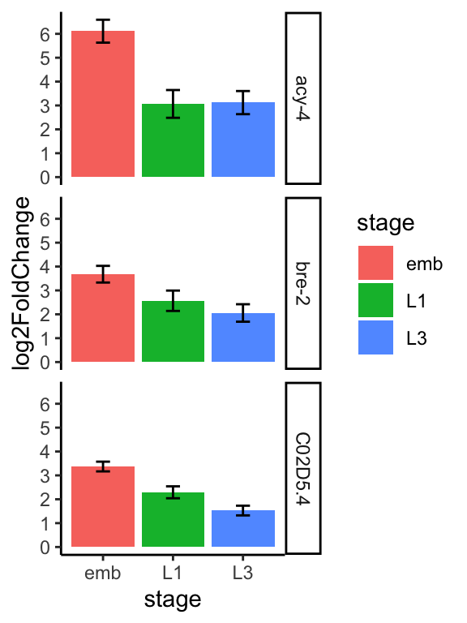

```r
novel_gene_plot <- ggplot(novel_gene_data, aes(x = stage, y = log2FoldChange, fill = stage)) +
  geom_bar(stat = "identity", position = "dodge") +
  geom_errorbar(aes(ymin=log2FoldChange-lfcSE, ymax=log2FoldChange+lfcSE), width=.2,
                 position=position_dodge(.9)) +
  scale_y_continuous(breaks = seq(0,6, by = 1)) +
  facet_grid(gene_name~.) +
  theme_classic()

novel_gene_plot
```

```r
# ggsave(plot = novel_gene_plot, filename = "../03_output/plots/novel_intestine_genes/220815_Novel_Intestine_Genes_log2FC.pdf", width = 3, height = 4)
```